# CSE4CG-PyOpenGL-Lab-05

## 5143135: Computer Graphics @ ZJU School of Software Technology

## Lab 5: Ray Casting

Welcome to **5143135: Computer Graphics** !

After attending this lab class, you are expected to

- Understand how to implement a simple ray casting application, which renders an image for a scene and outputs it as an image file, without OpenGL in Python.

### Part 1: Initialization

In Lecture 5 and 6, we discussed that ray casting produces the color value for each pixel, which corresponds to a ray, and figures out the visible scene point along each ray by finding the closest intersection. These tasks have been well supported by OpenGL as functions we practiced. Now, we say goodbye to PyOpenGL for while and aim to implement our application from scratch, in order to better understand the rendering mechanism.

Like mentioned, we do not need **PyOpenGL** in the program today, but only two other packages: **NumPy** and **matplotlib.pyplot**. The latter is a collection of functions that work like *MATLAB*. Each pyplot function makes some change to a figure (e.g., creates a figure, creates a plotting area in a figure, plots some lines in a plotting area, decorates the plot with labels, etc). We will use matplotlib.pyplot to export a file that contains the image after rendering.

Please check the following links for the installation and use of matplotlib.pyplot (Note you may not need to install it if using a **Conda**-based environment):

- https://matplotlib.org/users/installing.html
- https://matplotlib.org/api/pyplot_api.html

After both packages are successfully installed, we can import them at the beginning of the program, as follows.

```python
import numpy as np
import matplotlib.pyplot as plt
```

Let's first set up the image's parameters. We start with its width (in pixels), height (in pixels), and aspect ratio.

```python
# Image's width and height (in pixels)
w, h = 400, 300

# Image's aspect ratio
r = float(w) / h
```

Then, think about how to deal with the coordinates of the image? We mentioned a common practice of normalizing image coordinates from -1 to 1 **regardless of** the dimentions and aspect ratio of the image rectangle. However, to simplify the process, we consider the **aspect ratio** in our program to avoid the distortion, as follows.

```python
# Ranges of image coordinates
x_min, x_max = -1.0, 1.0
y_min, y_max = -1.0 / r, 1.0 / r
```

As our program generates an image, we need a container, such as a 3D array, to store its pixels as follows. The third dimension refers to RGB colors.

```python
# Output image data, in RGB colors
img = np.zeros((h, w, 3))
```

Then we move on to the camera. As we know, given the location of camera (i.e., eye point) **O**, a ray is casted towards a pixel on the image plane, whose coordiantes in the view coordinate system (i.e., clipping volume space) are denoted by **Q**. Note that Q's x and y coordiantes will be updated in the ray casting loop, but z coordinate is always 0, for Q is on the image plane. The **color** of the pixel at Q is **black** by default, and can be changed after ray casting. The following statements address the above information.

```python
# Camera point
O = np.array([0.0, 0.25, -1.0])

# The point in the image plane to which the camera points to (z is always 0)
# Its x and y coordinates will be updated in ray casting / tracing
# In the view coordinate system, the positive direction of z-axis is against the camera
Q = np.array([0.0, 0.0, 0.0])

# Image pixel's color (black by default, i.e. drawing nothing)
# It will be updated if the ray hits an object
color_pixel = np.zeros(3)

# White and black colors can be directly used somewhere else
color_white = np.ones(3)
color_black = np.zeros(3)
```

Regarding the lighting, we assume there is only one **point light** in the scene at location **L** in **white** color. It is necessary to specify some light parameters for color calculation at the later stage. In ray casting, we assume only **ambient** and **diffuse** reflections are provided by lighting.

```python
# Light's position
L = np.array([5.0, 5.0, -10.0])

# Light's color (white)
color_light = np.ones(3)

# Default light parameters
ambient     = 0.05
diffuse_c   = 1.0
```

Before entering the ray casting loop, we need to model a scene for rendering, which can be regarded as a list containing the objects, as follows.

```python
# List of objects
scene = []
```

As discussed in lectures, the ray casting loop iterates over all image pixels. We implement it as a **nested loop** (i.e., outer row-x, inner column-y). At the end of each iteration, the color of the corresponding pixel is updated in the image container. After the loop finishes, do not forget to output the image container as an image file to your machine.

```python
# Loop through all pixels in the image
for i, x in enumerate(np.linspace(x_min, x_max, w)):
    for j, y in enumerate(np.linspace(y_min, y_max, h)):
        color_pixel[:] = 0

        img[h - j - 1, i, :] = np.clip(color_pixel, 0, 1)

# Output the image file
plt.imsave('L5.png', img)
```

Note the *i* and *j* refer to indices along rows and columns, and *x* and *y* refer to coordinates. The former's corner system uses the **upper-left** corner as the origin (recall the screen coordinate system).

The rest of the task is to fulfill this framework.

### Part 2: Scene Modeling

In this lab class, we focus on two types of objects: **Plane** and **Sphere**, whose intersections with a ray have been introduced in Lecture 6. The following functions are used to create a plane and a sphere given necessary argument values.

```python
def add_sphere(position, radius, color):
    return dict(type='sphere',
                position=np.array(position),
                radius=np.array(radius),
                color=np.array(color))


def add_plane(position, normal):
    return dict(type='plane',
                position=np.array(position),
                normal=np.array(normal),
                color=lambda P : (color_white if (int(P[0]) % 2) == (int(P[2]) % 2) else color_black))
```

In particular, the *add_sphere* function reads information about center's location, radius and color, and returns a **dictionary** object consisiting of **key-value** pairs. Note its **type** is set *sphere* for identification, and all other values are stored in NumPy arrays.

Likewise, the *add_plane* function reads information about location and normal, and also returns a dictionary object. The plane's color, however, is represented by a lambda expression (i.e., a function) of an input *P*. Suppose *P* is the coordinates of a location, this lambda expression returns **white** if [x]\%2 = [z]\%2, and otherwise **black**. Think about what color pattern it leads to?

Using the above two functions, we can fill the scene container with desired objects. For example, the following statement refers to a scene in which four spheres are on a plane.

```python
# List of objects
scene = [
    add_sphere([1.0, 0.0, 1.0], 0.5, [1.0, 0.0, 0.0]),
    add_sphere([0.0, -0.1, 2.0], 0.4, [0.0, 0.0, 1.0]),
    add_sphere([-1.0, -0.2, 1.0], 0.3, [1.0, 1.0, 0.0]),
    add_sphere([-0.5, -0.3, 0.2], 0.2, [0.0, 1.0, 0.0]),
    add_plane([0.0, -0.5, 0.0], [0.0, 1.0, 0.0]),
]
```

Besides, we define the following functions to facilitate our task.

```python
# Normalize a vector represented by a NumPy array
def normalize(x):
    x /= np.linalg.norm(x)
    return x

# Get the normal at the point P given the object's information
def get_normal(obj, P):
    if obj['type'] == 'sphere':
        N = normalize(P - obj['position'])
    elif obj['type'] == 'plane':
        N = obj['normal']
    return N

# Get the color at the point P given the object's information
# Note if the color is a lambda expression, P is used as the input
def get_color(obj, P):
    color = obj['color']
    if not hasattr(color, '__len__'):
        color = color(P)
    return color
```

### Part 3: Ray-Object Intersection

Let's resume to the ray casting loop. In each iteration, we construct a ray from the camera **O** (which can be regarded as a vector **rayO** from the origin to the camera) to the pixel **Q**. If the *normalized* vector from **O** to **Q** is denoted by **rayD**, the ray can be fomulated as **rayO + t * rayD**. We can then find the intersection with the ray for each object in the scene and keep it if closest (i.e., smallest **t**). The following fucntion describes how to find the desired intersection given **rayO** and **rayD**.

```python
def cast_ray(rayO, rayD):
    # Find first point of intersection with the scene.
    t = np.inf
    for i, obj in enumerate(scene):
        t_obj = intersect(rayO, rayD, obj)
        if t_obj < t:
            t, obj_idx = t_obj, i

    # Return None if the ray does not intersect any object.
    if t == np.inf:
        return

    # Find the object.
    obj = scene[obj_idx]

    # Find the point of intersection on the object.
    P = rayO + rayD * t

    # Find properties of the object.
    N = get_normal(obj, P)
    color = get_color(obj, P)
    toL = normalize(L - P)

    # Start computing the color.
    color_ray = ambient

    # Lambert shading (diffuse).
    color_ray += obj.get('diffuse_c', diffuse_c) * max(np.dot(N, toL), 0) * color

    return obj, P, N, color_ray
```

As you may find, the pixel's color, as the result of lighting effects on the objects, has been specified in the **cast_ray** function. In this subject, we use the **Phong reflection model** for lighting, which includes three types of reflections: **ambient**, **diffuse** and **specular**, which are illustrated in the figure below

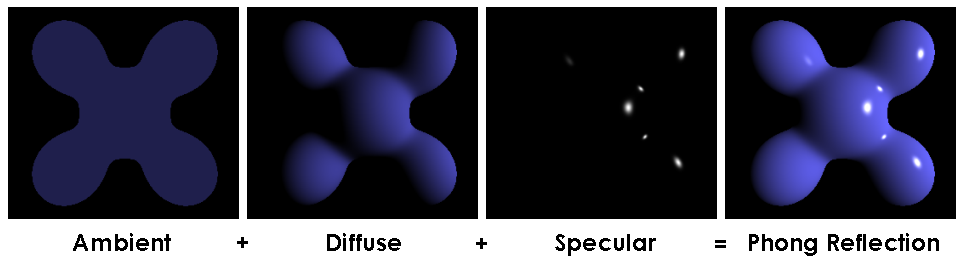

In ray casting, we limit our focus on **ambient** and **diffuse** reflections, as mentioned above. **Ambient reflection** refers to the small amount of light that is scattered about the entire scene (i.e., a scene-specific constant value). **Diffuse reflection** refers to the reflection of light from a surface such that a ray incident on the surface is scattered at many angles, whose contribution is non-negative and usually the dot product of normal and light vector. We may scale the diffuse relection by multiplying a self-defined coefficient.

The key of the function lies in calling another function **intersect**, which handles the intersecton with the ray for an object. We define the **intersect** function, as follows, that handles *ray-plane* and *ray-sphere* intersections.

```python
def intersect(O, D, obj):
    if obj['type'] == 'plane':
        return intersect_plane(O, D, obj['position'], obj['normal'])
    elif obj['type'] == 'sphere':
        return intersect_sphere(O, D, obj['position'], obj['radius'])

def intersect_plane(O, D, P, N):
    # Return the distance from O to the intersection of the ray (O, D) with the
    # plane (P, N), or +inf if there is no intersection.
    # O and P are 3D points, D and N (normal) are normalized vectors.
    denominator = np.dot(N, D)
    if np.abs(denominator) < 1e-6:
        return np.inf

    t = (np.dot(N, P) - np.dot(N, O)) / denominator
    if t < 0:
        return np.inf
    return t

def intersect_sphere(O, D, S, R):
    # Return the distance from O to the intersection of the ray (O, D) with the
    # sphere (S, R), or +inf if there is no intersection.
    # O and S are 3D points, D (direction) is a normalized vector, R is a scalar.
    # It is necessary to consider the case that the sphere's centre is not at the origin
    # H(P) = (P - S) * (P - S) - R * R = 0
    OS = O - S

    a = np.dot(D, D)
    b = 2 * np.dot(D, OS)
    c = np.dot(OS, OS) - R * R
    discriminant = b * b - 4 * a * c

    if discriminant > 0:
        d = np.sqrt(discriminant)

        t_0 = (-b + d) / (2 * a)
        t_1 = (-b - d) / (2 * a)

        if t_0 < 0:
            return np.inf
        elif t_1 < 0:
            return t_0
        else:
            return t_1
    else:
        return np.inf
```

Note we provide one interface for two intersections by defining helper functions **intersect_plane** and **intersect_sphere**. The **intersect** function returns *positive infinity* if no intersection is deteced.

### Part 4: Finalization

Given the above defined functions, we resume to the main body of the program and finalize the ray casting loop as follow.

```python
# Loop through all pixels in the image
for i, x in enumerate(np.linspace(x_min, x_max, w)):
    for j, y in enumerate(np.linspace(y_min, y_max, h)):
        color_pixel[:] = 0

        Q[0] = x
        Q[1] = y
        D = normalize(Q - O)
        depth = 0
        reflection = 1.0

        rayO, rayD = O, D
        flag = cast_ray(rayO, rayD)
        if not flag:
            continue
        obj, P, N, color_ray = flag

        color_pixel = color_ray

        img[h - j - 1, i, :] = np.clip(color_pixel, 0, 1)
```

In each iteration, if the **cast_ray** function returns the information of a valid intersection, the pixel's color will then be updated and given to the image container (Note the difference of coordinates, and the relationship of x-y plane and column-row matrix); Otherwise, the program skips the rest of the iteration and moves forward to the next one.

Now, please organize the program as follows and run it to see what happpens.

```python
import numpy as np
import matplotlib.pyplot as plt


def normalize(x):
    x /= np.linalg.norm(x)
    return x

def intersect_plane(O, D, P, N):
    # Return the distance from O to the intersection of the ray (O, D) with the
    # plane (P, N), or +inf if there is no intersection.
    # O and P are 3D points, D and N (normal) are normalized vectors.
    denominator = np.dot(N, D)
    if np.abs(denominator) < 1e-6:
        return np.inf

    t = (np.dot(N, P) - np.dot(N, O)) / denominator
    if t < 0:
        return np.inf
    return t

def intersect_sphere(O, D, S, R):
    # Return the distance from O to the intersection of the ray (O, D) with the
    # sphere (S, R), or +inf if there is no intersection.
    # O and S are 3D points, D (direction) is a normalized vector, R is a scalar.
    # It is necessary to consider the case that the sphere's centre is not at the origin
    # H(P) = (P - S) * (P - S) - R * R = 0
    OS = O - S

    a = np.dot(D, D)
    b = 2 * np.dot(D, OS)
    c = np.dot(OS, OS) - R * R
    discriminant = b * b - 4 * a * c

    if discriminant > 0:
        d = np.sqrt(discriminant)

        t_0 = (-b + d) / (2 * a)
        t_1 = (-b - d) / (2 * a)

        if t_0 < 0:
            return np.inf
        elif t_1 < 0:
            return t_0
        else:
            return t_1
    else:
        return np.inf


def intersect(O, D, obj):
    if obj['type'] == 'plane':
        return intersect_plane(O, D, obj['position'], obj['normal'])
    elif obj['type'] == 'sphere':
        return intersect_sphere(O, D, obj['position'], obj['radius'])


def get_normal(obj, P):
    if obj['type'] == 'sphere':
        N = normalize(P - obj['position'])
    elif obj['type'] == 'plane':
        N = obj['normal']
    return N


def get_color(obj, P):
    color = obj['color']
    if not hasattr(color, '__len__'):
        color = color(P)
    return color

def cast_ray(rayO, rayD):
    # Find first point of intersection with the scene.
    t = np.inf
    for i, obj in enumerate(scene):
        t_obj = intersect(rayO, rayD, obj)
        if t_obj < t:
            t, obj_idx = t_obj, i

    # Return None if the ray does not intersect any object.
    if t == np.inf:
        return

    # Find the object.
    obj = scene[obj_idx]

    # Find the point of intersection on the object.
    P = rayO + rayD * t

    # Find properties of the object.
    N = get_normal(obj, P)
    color = get_color(obj, P)
    toL = normalize(L - P)

    # Start computing the color.
    color_ray = ambient

    # Lambert shading (diffuse).
    color_ray += obj.get('diffuse_c', diffuse_c) * max(np.dot(N, toL), 0) * color

    return obj, P, N, color_ray


def add_sphere(position, radius, color):
    return dict(type='sphere',
                position=np.array(position),
                radius=np.array(radius),
                color=np.array(color))


def add_plane(position, normal):
    return dict(type='plane',
                position=np.array(position),
                normal=np.array(normal),
                color=lambda P : (color_white if (int(P[0]) % 2) == (int(P[2]) % 2) else color_black))

# Image's width and height (in pixels)
w, h = 400, 300

# Image's aspect ratio
r = float(w) / h

# Ranges of image coordinates (-1 <= x <= 1, -1 <= y <= 1)
# But the actual y coordinates need to be divided by the aspect ratio, why?
x_min, x_max = -1.0, 1.0
y_min, y_max = -1.0 / r, 1.0 / r

# Output image data, in RGB colors
img = np.zeros((h, w, 3))

# Camera point
O = np.array([0.0, 0.25, -1.0])

# The point in the image plane to which the camera points to (z is always 0)
# Its x and y coordinates will be updated in ray casting / tracing
# In the view coordinate system, the positive direction of z-axis is against the camera
Q = np.array([0.0, 0.0, 0.0])

# Image pixel's color (black by default, i.e. drawing nothing)
# It will be updated if the ray hits an object
color_pixel = np.zeros(3)

color_white = np.ones(3)
color_black = np.zeros(3)

# Light's position
L = np.array([5.0, 5.0, -10.0])

# Light's color (white)
color_light = np.ones(3)

# Default light parameters
ambient     = 0.05
diffuse_c   = 1.0

# List of objects
scene = [
    add_sphere([1.0, 0.0, 1.0], 0.5, [1.0, 0.0, 0.0]),
    add_sphere([0.0, -0.1, 2.0], 0.4, [0.0, 0.0, 1.0]),
    add_sphere([-1.0, -0.2, 1.0], 0.3, [1.0, 1.0, 0.0]),
    add_sphere([-0.5, -0.3, 0.2], 0.2, [0.0, 1.0, 0.0]),
    add_plane([0.0, -0.5, 0.0], [0.0, 1.0, 0.0]),
]

# Loop through all pixels in the image
for i, x in enumerate(np.linspace(x_min, x_max, w)):
    for j, y in enumerate(np.linspace(y_min, y_max, h)):
        color_pixel[:] = 0

        Q[0] = x
        Q[1] = y
        D = normalize(Q - O)
        depth = 0
        reflection = 1.0

        rayO, rayD = O, D
        flag = cast_ray(rayO, rayD)
        if not flag:
            continue
        obj, P, N, color_ray = flag

        color_pixel = color_ray

        img[h - j - 1, i, :] = np.clip(color_pixel, 0, 1)

plt.imsave('L5.png', img)
```

After waiting a few seconds (depending on your machine's specs), an image file named *L5.png* is created in the folder where the Python file is located. It describes the scene that we speficied in the program, as follows.

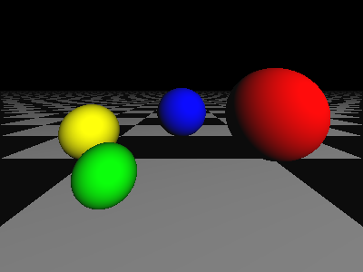

### Questions

#### Q1: Think about why the plane's color is in a chess-board pattern.

#### Q2: Think about what else is / are needed to improve the realisticity of the image.

#### Q3: Think about why the program is NOT very efficient (i.e., it is not realtime) and how you can improve it.